# Risk Factor Analysis

## Outcome Variable

**Outcome Variable:** whz

## Predictor Variables

**Intervention Variable:** exclfeed36

**Adjustment Set:**

- arm
- sex
- brthmon
- W_mage
- meducyrs
- feducyrs
- hhwealth_quart
- hfoodsec
- W_mhtcm
- W_mwtkg
- W_mbmi
- vagbrth
- W_gagebrth
- W_birthwt
- W_birthlen
- W_nrooms
- W_nchldlt5
- month
- W_parity
- impfloor
- impsan
- safeh20
- delta_W_mage
- delta_meducyrs
- delta_feducyrs
- delta_hhwealth_quart
- delta_hfoodsec
- delta_W_mhtcm
- delta_W_mwtkg
- delta_W_mbmi
- delta_vagbrth
- delta_W_gagebrth
- delta_W_birthwt
- delta_W_birthlen
- delta_W_nrooms
- delta_W_nchldlt5
- delta_month
- delta_W_parity
- delta_impfloor
- delta_impsan
- delta_safeh20

## Stratifying Variables

The analysis was stratified on these variable(s):

- agecat
- studyid
- country

## Data Summary

| agecat | studyid | country | exclfeed36 | n_cell | n |
| --- | --- | --- | --- | --- | --- |
| Birth | ki0047075b-MAL-ED | BANGLADESH | 1 | 31 | 208 |
| Birth | ki0047075b-MAL-ED | BANGLADESH | 0 | 177 | 208 |
| Birth | ki0047075b-MAL-ED | BRAZIL | 1 | 4 | 62 |
| Birth | ki0047075b-MAL-ED | BRAZIL | 0 | 58 | 62 |
| Birth | ki0047075b-MAL-ED | INDIA | 1 | 1 | 40 |
| Birth | ki0047075b-MAL-ED | INDIA | 0 | 39 | 40 |
| Birth | ki0047075b-MAL-ED | NEPAL | 1 | 0 | 25 |
| Birth | ki0047075b-MAL-ED | NEPAL | 0 | 25 | 25 |
| Birth | ki0047075b-MAL-ED | PERU | 1 | 5 | 218 |
| Birth | ki0047075b-MAL-ED | PERU | 0 | 213 | 218 |
| Birth | ki0047075b-MAL-ED | SOUTH AFRICA | 1 | 1 | 104 |
| Birth | ki0047075b-MAL-ED | SOUTH AFRICA | 0 | 103 | 104 |
| Birth | ki0047075b-MAL-ED | TANZANIA, UNITED REPUBLIC OF | 1 | 0 | 111 |
| Birth | ki0047075b-MAL-ED | TANZANIA, UNITED REPUBLIC OF | 0 | 111 | 111 |
| Birth | ki1000108-CMC-V-BCS-2002 | INDIA | 1 | 3 | 3 |
| Birth | ki1000108-CMC-V-BCS-2002 | INDIA | 0 | 0 | 3 |
| Birth | ki1000108-IRC | INDIA | 1 | 0 | 3 |
| Birth | ki1000108-IRC | INDIA | 0 | 3 | 3 |
| Birth | ki1000109-EE | PAKISTAN | 1 | 2 | 6 |
| Birth | ki1000109-EE | PAKISTAN | 0 | 4 | 6 |
| Birth | ki1017093b-PROVIDE | BANGLADESH | 1 | 115 | 483 |
| Birth | ki1017093b-PROVIDE | BANGLADESH | 0 | 368 | 483 |
| Birth | ki1101329-Keneba | GAMBIA | 1 | 4 | 9 |
| Birth | ki1101329-Keneba | GAMBIA | 0 | 5 | 9 |
| Birth | ki1113344-GMS-Nepal | NEPAL | 1 | 396 | 491 |
| Birth | ki1113344-GMS-Nepal | NEPAL | 0 | 95 | 491 |
| Birth | kiGH5241-JiVitA-3 | BANGLADESH | 1 | 8189 | 10491 |
| Birth | kiGH5241-JiVitA-3 | BANGLADESH | 0 | 2302 | 10491 |
| Birth | kiGH5241-JiVitA-4 | BANGLADESH | 1 | 1711 | 2128 |
| Birth | kiGH5241-JiVitA-4 | BANGLADESH | 0 | 417 | 2128 |

[output cut: 66 more lines]

The following strata were considered:

- agecat: 24 months, studyid: ki0047075b-MAL-ED, country: BANGLADESH
- agecat: 24 months, studyid: ki0047075b-MAL-ED, country: BRAZIL
- agecat: 24 months, studyid: ki0047075b-MAL-ED, country: INDIA
- agecat: 24 months, studyid: ki0047075b-MAL-ED, country: NEPAL
- agecat: 24 months, studyid: ki0047075b-MAL-ED, country: PERU
- agecat: 24 months, studyid: ki0047075b-MAL-ED, country: SOUTH AFRICA
- agecat: 24 months, studyid: ki0047075b-MAL-ED, country: TANZANIA, UNITED REPUBLIC OF
- agecat: 24 months, studyid: ki1000108-CMC-V-BCS-2002, country: INDIA
- agecat: 24 months, studyid: ki1000108-IRC, country: INDIA
- agecat: 24 months, studyid: ki1000109-EE, country: PAKISTAN
- agecat: 24 months, studyid: ki1017093b-PROVIDE, country: BANGLADESH
- agecat: 24 months, studyid: ki1101329-Keneba, country: GAMBIA
- agecat: 24 months, studyid: ki1113344-GMS-Nepal, country: NEPAL
- agecat: 24 months, studyid: ki1148112-LCNI-5, country: MALAWI
- agecat: 24 months, studyid: kiGH5241-JiVitA-3, country: BANGLADESH
- agecat: 24 months, studyid: kiGH5241-JiVitA-4, country: BANGLADESH
- agecat: 6 months, studyid: ki0047075b-MAL-ED, country: BANGLADESH
- agecat: 6 months, studyid: ki0047075b-MAL-ED, country: BRAZIL
- agecat: 6 months, studyid: ki0047075b-MAL-ED, country: INDIA
- agecat: 6 months, studyid: ki0047075b-MAL-ED, country: NEPAL
- agecat: 6 months, studyid: ki0047075b-MAL-ED, country: PERU
- agecat: 6 months, studyid: ki0047075b-MAL-ED, country: SOUTH AFRICA
- agecat: 6 months, studyid: ki0047075b-MAL-ED, country: TANZANIA, UNITED REPUBLIC OF
- agecat: 6 months, studyid: ki1000108-CMC-V-BCS-2002, country: INDIA
- agecat: 6 months, studyid: ki1000108-IRC, country: INDIA
- agecat: 6 months, studyid: ki1000109-EE, country: PAKISTAN
- agecat: 6 months, studyid: ki1000304b-SAS-FoodSuppl, country: INDIA
- agecat: 6 months, studyid: ki1017093b-PROVIDE, country: BANGLADESH
- agecat: 6 months, studyid: ki1101329-Keneba, country: GAMBIA
- agecat: 6 months, studyid: ki1113344-GMS-Nepal, country: NEPAL
- agecat: 6 months, studyid: ki1148112-LCNI-5, country: MALAWI
- agecat: 6 months, studyid: kiGH5241-JiVitA-3, country: BANGLADESH
- agecat: 6 months, studyid: kiGH5241-JiVitA-4, country: BANGLADESH
- agecat: Birth, studyid: ki0047075b-MAL-ED, country: BANGLADESH
- agecat: Birth, studyid: ki0047075b-MAL-ED, country: BRAZIL
- agecat: Birth, studyid: ki0047075b-MAL-ED, country: INDIA
- agecat: Birth, studyid: ki0047075b-MAL-ED, country: NEPAL
- agecat: Birth, studyid: ki0047075b-MAL-ED, country: PERU
- agecat: Birth, studyid: ki0047075b-MAL-ED, country: SOUTH AFRICA
- agecat: Birth, studyid: ki0047075b-MAL-ED, country: TANZANIA, UNITED REPUBLIC OF
- agecat: Birth, studyid: ki1000108-CMC-V-BCS-2002, country: INDIA
- agecat: Birth, studyid: ki1000108-IRC, country: INDIA
- agecat: Birth, studyid: ki1000109-EE, country: PAKISTAN
- agecat: Birth, studyid: ki1017093b-PROVIDE, country: BANGLADESH
- agecat: Birth, studyid: ki1101329-Keneba, country: GAMBIA
- agecat: Birth, studyid: ki1113344-GMS-Nepal, country: NEPAL
- agecat: Birth, studyid: kiGH5241-JiVitA-3, country: BANGLADESH
- agecat: Birth, studyid: kiGH5241-JiVitA-4, country: BANGLADESH

### Dropped Strata

Some strata were dropped due to rare outcomes:

- agecat: Birth, studyid: ki0047075b-MAL-ED, country: BRAZIL
- agecat: Birth, studyid: ki0047075b-MAL-ED, country: INDIA
- agecat: Birth, studyid: ki0047075b-MAL-ED, country: NEPAL
- agecat: Birth, studyid: ki0047075b-MAL-ED, country: SOUTH AFRICA
- agecat: Birth, studyid: ki0047075b-MAL-ED, country: TANZANIA, UNITED REPUBLIC OF
- agecat: Birth, studyid: ki1000108-CMC-V-BCS-2002, country: INDIA
- agecat: Birth, studyid: ki1000108-IRC, country: INDIA
- agecat: Birth, studyid: ki1000109-EE, country: PAKISTAN
- agecat: Birth, studyid: ki1101329-Keneba, country: GAMBIA
- agecat: 6 months, studyid: ki0047075b-MAL-ED, country: NEPAL
- agecat: 6 months, studyid: ki0047075b-MAL-ED, country: SOUTH AFRICA
- agecat: 6 months, studyid: ki0047075b-MAL-ED, country: TANZANIA, UNITED REPUBLIC OF
- agecat: 6 months, studyid: ki1000108-CMC-V-BCS-2002, country: INDIA
- agecat: 6 months, studyid: ki1000108-IRC, country: INDIA
- agecat: 6 months, studyid: ki1000109-EE, country: PAKISTAN
- agecat: 6 months, studyid: ki1000304b-SAS-FoodSuppl, country: INDIA
- agecat: 24 months, studyid: ki0047075b-MAL-ED, country: NEPAL
- agecat: 24 months, studyid: ki0047075b-MAL-ED, country: PERU
- agecat: 24 months, studyid: ki0047075b-MAL-ED, country: SOUTH AFRICA
- agecat: 24 months, studyid: ki0047075b-MAL-ED, country: TANZANIA, UNITED REPUBLIC OF
- agecat: 24 months, studyid: ki1000108-CMC-V-BCS-2002, country: INDIA
- agecat: 24 months, studyid: ki1000108-IRC, country: INDIA
- agecat: 24 months, studyid: ki1000109-EE, country: PAKISTAN

## Methods Detail

We’re interested in the causal parameters $E[Y_a]$ for all values of $a \in \mathcal{A}$. These parameters represent the mean outcome if, possibly contrary to fact, we intervened to set all units to have $A=a$. Under the randomization and positivity assumptions, these are identified by the statistical parameters $\psi_a=E_W[E_{Y|A,W}(Y|A=a,W)]$. In addition, we’re interested in the mean of $Y$, $E[Y]$ under no intervention (the observed mean). We will estimate these parameters by using SuperLearner to fit the relevant likelihood factors – $E_{Y|A,W}(Y|A=a,W)$ and $p(A=a|W)$, and then updating our likelihood fit using a joint TMLE.

For unadjusted analyses ($W=\{\}$), initial likelihoods were estimated using Lrnr_glm to estimate the simple $E(Y|A)$ and Lrnr_mean to estimate $p(A)$. For adjusted analyses, a small library containing Lrnr_glmnet, Lrnr_xgboost, and Lrnr_mean was used.

Having estimated these parameters, we will then use the delta method to estimate relative risks and attributable risks relative to a prespecified baseline level of $A$.

# Results Detail

## Results Plots

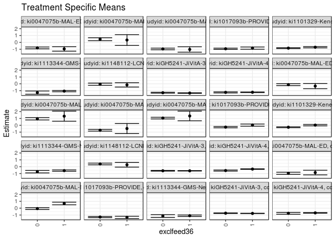

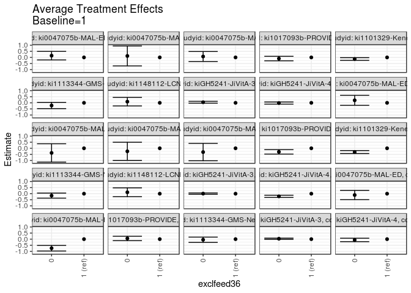

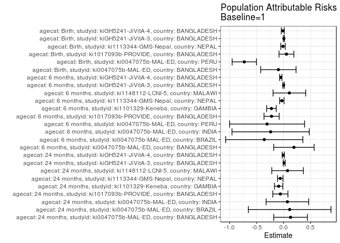

## Results Table

### Parameter: TSM

| agecat | studyid | country | intervention_level | baseline_level | estimate | ci_lower | ci_upper |
| --- | --- | --- | --- | --- | --- | --- | --- |
| Birth | ki0047075b-MAL-ED | BANGLADESH | 1 | NA | -0.8518869 | -1.1939189 | -0.5098548 |
| Birth | ki0047075b-MAL-ED | BANGLADESH | 0 | NA | -0.9593888 | -1.1202766 | -0.7985009 |
| Birth | ki0047075b-MAL-ED | PERU | 1 | NA | 0.6820000 | 0.4886003 | 0.8753997 |
| Birth | ki0047075b-MAL-ED | PERU | 0 | NA | -0.0629108 | -0.1888962 | 0.0630746 |
| Birth | ki1017093b-PROVIDE | BANGLADESH | 1 | NA | -1.3504599 | -1.5157274 | -1.1851923 |
| Birth | ki1017093b-PROVIDE | BANGLADESH | 0 | NA | -1.2929244 | -1.3808242 | -1.2050246 |
| Birth | ki1113344-GMS-Nepal | NEPAL | 1 | NA | -1.0983977 | -1.2063860 | -0.9904094 |
| Birth | ki1113344-GMS-Nepal | NEPAL | 0 | NA | -1.1472382 | -1.3478135 | -0.9466630 |
| Birth | kiGH5241-JiVitA-3 | BANGLADESH | 1 | NA | -0.7667902 | -0.7927340 | -0.7408464 |
| Birth | kiGH5241-JiVitA-3 | BANGLADESH | 0 | NA | -0.7338179 | -0.7784892 | -0.6891465 |
| Birth | kiGH5241-JiVitA-4 | BANGLADESH | 1 | NA | -0.6885790 | -0.7446327 | -0.6325253 |
| Birth | kiGH5241-JiVitA-4 | BANGLADESH | 0 | NA | -0.7549329 | -0.8902789 | -0.6195869 |
| 6 months | ki0047075b-MAL-ED | BANGLADESH | 1 | NA | -0.3285144 | -0.7119436 | 0.0549149 |
| 6 months | ki0047075b-MAL-ED | BANGLADESH | 0 | NA | -0.1208448 | -0.2589406 | 0.0172511 |
| 6 months | ki0047075b-MAL-ED | BRAZIL | 1 | NA | 1.3294765 | 0.5956160 | 2.0633370 |
| 6 months | ki0047075b-MAL-ED | BRAZIL | 0 | NA | 0.9479189 | 0.7783070 | 1.1175307 |
| 6 months | ki0047075b-MAL-ED | INDIA | 1 | NA | -0.4772222 | -1.2114182 | 0.2569738 |
| 6 months | ki0047075b-MAL-ED | INDIA | 0 | NA | -0.7260789 | -0.8553450 | -0.5968127 |
| 6 months | ki0047075b-MAL-ED | PERU | 1 | NA | 1.3608333 | 0.6586581 | 2.0630086 |
| 6 months | ki0047075b-MAL-ED | PERU | 0 | NA | 1.0483020 | 0.9246012 | 1.1720028 |
| 6 months | ki1017093b-PROVIDE | BANGLADESH | 1 | NA | 0.0227966 | -0.1374211 | 0.1830142 |
| 6 months | ki1017093b-PROVIDE | BANGLADESH | 0 | NA | -0.2718432 | -0.3666025 | -0.1770840 |
| 6 months | ki1101329-Keneba | GAMBIA | 1 | NA | 0.0229425 | -0.0826009 | 0.1284858 |
| 6 months | ki1101329-Keneba | GAMBIA | 0 | NA | -0.2873662 | -0.3508454 | -0.2238870 |
| 6 months | ki1113344-GMS-Nepal | NEPAL | 1 | NA | -0.5685324 | -0.6685056 | -0.4685592 |
| 6 months | ki1113344-GMS-Nepal | NEPAL | 0 | NA | -0.7251564 | -0.9084364 | -0.5418765 |
| 6 months | ki1148112-LCNI-5 | MALAWI | 1 | NA | 0.2840944 | -0.0558411 | 0.6240300 |
| 6 months | ki1148112-LCNI-5 | MALAWI | 0 | NA | 0.4013273 | 0.2741869 | 0.5284677 |
| 6 months | kiGH5241-JiVitA-3 | BANGLADESH | 1 | NA | -0.6004913 | -0.6297031 | -0.5712795 |
| 6 months | kiGH5241-JiVitA-3 | BANGLADESH | 0 | NA | -0.5936457 | -0.6419782 | -0.5453132 |
| 6 months | kiGH5241-JiVitA-4 | BANGLADESH | 1 | NA | -0.3453242 | -0.3909530 | -0.2996955 |
| 6 months | kiGH5241-JiVitA-4 | BANGLADESH | 0 | NA | -0.5598762 | -0.6388855 | -0.4808668 |
| 24 months | ki0047075b-MAL-ED | BANGLADESH | 1 | NA | -0.9507092 | -1.2737602 | -0.6276583 |
| 24 months | ki0047075b-MAL-ED | BANGLADESH | 0 | NA | -0.8065743 | -0.9391818 | -0.6739667 |
| 24 months | ki0047075b-MAL-ED | BRAZIL | 1 | NA | 0.3453156 | -0.4428115 | 1.1334427 |
| 24 months | ki0047075b-MAL-ED | BRAZIL | 0 | NA | 0.4640031 | 0.2492239 | 0.6787823 |
| 24 months | ki0047075b-MAL-ED | INDIA | 1 | NA | -1.0300000 | -1.4230980 | -0.6369020 |
| 24 months | ki0047075b-MAL-ED | INDIA | 0 | NA | -0.9557907 | -1.0760589 | -0.8355225 |
| 24 months | ki1017093b-PROVIDE | BANGLADESH | 1 | NA | -0.8359057 | -0.9961242 | -0.6756872 |
| 24 months | ki1017093b-PROVIDE | BANGLADESH | 0 | NA | -0.9312511 | -1.0267322 | -0.8357700 |
| 24 months | ki1101329-Keneba | GAMBIA | 1 | NA | -0.7067307 | -0.7996477 | -0.6138136 |
| 24 months | ki1101329-Keneba | GAMBIA | 0 | NA | -0.8375556 | -0.8999440 | -0.7751673 |
| 24 months | ki1113344-GMS-Nepal | NEPAL | 1 | NA | -1.0628597 | -1.1616157 | -0.9641037 |
| 24 months | ki1113344-GMS-Nepal | NEPAL | 0 | NA | -1.2820858 | -1.5215703 | -1.0426013 |
| 24 months | ki1148112-LCNI-5 | MALAWI | 1 | NA | -0.1519008 | -0.4617314 | 0.1579298 |
| 24 months | ki1148112-LCNI-5 | MALAWI | 0 | NA | -0.0546419 | -0.2184403 | 0.1091566 |
| 24 months | kiGH5241-JiVitA-3 | BANGLADESH | 1 | NA | -1.3475470 | -1.3865632 | -1.3085308 |
| 24 months | kiGH5241-JiVitA-3 | BANGLADESH | 0 | NA | -1.2977211 | -1.3644360 | -1.2310062 |
| 24 months | kiGH5241-JiVitA-4 | BANGLADESH | 1 | NA | -1.2292581 | -1.2715006 | -1.1870157 |
| 24 months | kiGH5241-JiVitA-4 | BANGLADESH | 0 | NA | -1.2458864 | -1.3246698 | -1.1671031 |

### Parameter: E(Y)

| agecat | studyid | country | intervention_level | baseline_level | estimate | ci_lower | ci_upper |
| --- | --- | --- | --- | --- | --- | --- | --- |
| Birth | ki0047075b-MAL-ED | BANGLADESH | NA | NA | -0.9474038 | -1.0929246 | -0.8018831 |
| Birth | ki0047075b-MAL-ED | PERU | NA | NA | -0.0458257 | -0.1696487 | 0.0779973 |
| Birth | ki1017093b-PROVIDE | BANGLADESH | NA | NA | -1.2966874 | -1.3774293 | -1.2159454 |
| Birth | ki1113344-GMS-Nepal | NEPAL | NA | NA | -1.1085743 | -1.2077878 | -1.0093609 |
| Birth | kiGH5241-JiVitA-3 | BANGLADESH | NA | NA | -0.7602278 | -0.7829387 | -0.7375169 |
| Birth | kiGH5241-JiVitA-4 | BANGLADESH | NA | NA | -0.7018985 | -0.7560164 | -0.6477806 |
| 6 months | ki0047075b-MAL-ED | BANGLADESH | NA | NA | -0.1361806 | -0.2655204 | -0.0068407 |
| 6 months | ki0047075b-MAL-ED | BRAZIL | NA | NA | 0.9717225 | 0.8073791 | 1.1360658 |
| 6 months | ki0047075b-MAL-ED | INDIA | NA | NA | -0.7164664 | -0.8440835 | -0.5888492 |
| 6 months | ki0047075b-MAL-ED | PERU | NA | NA | 1.0551961 | 0.9331945 | 1.1771976 |
| 6 months | ki1017093b-PROVIDE | BANGLADESH | NA | NA | -0.1990907 | -0.2817968 | -0.1163845 |
| 6 months | ki1101329-Keneba | GAMBIA | NA | NA | -0.2009461 | -0.2562412 | -0.1456509 |
| 6 months | ki1113344-GMS-Nepal | NEPAL | NA | NA | -0.6001075 | -0.6890924 | -0.5111227 |
| 6 months | ki1148112-LCNI-5 | MALAWI | NA | NA | 0.3925000 | 0.2735307 | 0.5114693 |
| 6 months | kiGH5241-JiVitA-3 | BANGLADESH | NA | NA | -0.5994135 | -0.6250748 | -0.5737521 |
| 6 months | kiGH5241-JiVitA-4 | BANGLADESH | NA | NA | -0.3960017 | -0.4356255 | -0.3563778 |
| 24 months | ki0047075b-MAL-ED | BANGLADESH | NA | NA | -0.8201887 | -0.9423967 | -0.6979806 |
| 24 months | ki0047075b-MAL-ED | BRAZIL | NA | NA | 0.4592308 | 0.2528453 | 0.6656163 |
| 24 months | ki0047075b-MAL-ED | INDIA | NA | NA | -0.9587723 | -1.0752995 | -0.8422452 |
| 24 months | ki1017093b-PROVIDE | BANGLADESH | NA | NA | -0.8945581 | -0.9774087 | -0.8117074 |
| 24 months | ki1101329-Keneba | GAMBIA | NA | NA | -0.7973955 | -0.8498696 | -0.7449213 |
| 24 months | ki1113344-GMS-Nepal | NEPAL | NA | NA | -1.1236255 | -1.2167712 | -1.0304797 |
| 24 months | ki1148112-LCNI-5 | MALAWI | NA | NA | -0.0770652 | -0.2204213 | 0.0662909 |
| 24 months | kiGH5241-JiVitA-3 | BANGLADESH | NA | NA | -1.3365001 | -1.3704041 | -1.3025961 |
| 24 months | kiGH5241-JiVitA-4 | BANGLADESH | NA | NA | -1.2344089 | -1.2708428 | -1.1979750 |

### Parameter: ATE

| agecat | studyid | country | intervention_level | baseline_level | estimate | ci_lower | ci_upper |
| --- | --- | --- | --- | --- | --- | --- | --- |
| Birth | ki0047075b-MAL-ED | BANGLADESH | 1 | 1 | 0.0000000 | 0.0000000 | 0.0000000 |
| Birth | ki0047075b-MAL-ED | BANGLADESH | 0 | 1 | -0.1075019 | -0.4862122 | 0.2712083 |
| Birth | ki0047075b-MAL-ED | PERU | 1 | 1 | 0.0000000 | 0.0000000 | 0.0000000 |
| Birth | ki0047075b-MAL-ED | PERU | 0 | 1 | -0.7449108 | -0.9757262 | -0.5140954 |
| Birth | ki1017093b-PROVIDE | BANGLADESH | 1 | 1 | 0.0000000 | 0.0000000 | 0.0000000 |
| Birth | ki1017093b-PROVIDE | BANGLADESH | 0 | 1 | 0.0575355 | -0.1225943 | 0.2376652 |
| Birth | ki1113344-GMS-Nepal | NEPAL | 1 | 1 | 0.0000000 | 0.0000000 | 0.0000000 |
| Birth | ki1113344-GMS-Nepal | NEPAL | 0 | 1 | -0.0488405 | -0.2657034 | 0.1680224 |
| Birth | kiGH5241-JiVitA-3 | BANGLADESH | 1 | 1 | 0.0000000 | 0.0000000 | 0.0000000 |
| Birth | kiGH5241-JiVitA-3 | BANGLADESH | 0 | 1 | 0.0329723 | -0.0180588 | 0.0840035 |
| Birth | kiGH5241-JiVitA-4 | BANGLADESH | 1 | 1 | 0.0000000 | 0.0000000 | 0.0000000 |
| Birth | kiGH5241-JiVitA-4 | BANGLADESH | 0 | 1 | -0.0663538 | -0.2085429 | 0.0758352 |
| 6 months | ki0047075b-MAL-ED | BANGLADESH | 1 | 1 | 0.0000000 | 0.0000000 | 0.0000000 |
| 6 months | ki0047075b-MAL-ED | BANGLADESH | 0 | 1 | 0.2076696 | -0.2014596 | 0.6167988 |
| 6 months | ki0047075b-MAL-ED | BRAZIL | 1 | 1 | 0.0000000 | 0.0000000 | 0.0000000 |
| 6 months | ki0047075b-MAL-ED | BRAZIL | 0 | 1 | -0.3815576 | -1.1350452 | 0.3719300 |
| 6 months | ki0047075b-MAL-ED | INDIA | 1 | 1 | 0.0000000 | 0.0000000 | 0.0000000 |
| 6 months | ki0047075b-MAL-ED | INDIA | 0 | 1 | -0.2488566 | -0.9943454 | 0.4966322 |
| 6 months | ki0047075b-MAL-ED | PERU | 1 | 1 | 0.0000000 | 0.0000000 | 0.0000000 |
| 6 months | ki0047075b-MAL-ED | PERU | 0 | 1 | -0.3125313 | -1.0255194 | 0.4004567 |
| 6 months | ki1017093b-PROVIDE | BANGLADESH | 1 | 1 | 0.0000000 | 0.0000000 | 0.0000000 |
| 6 months | ki1017093b-PROVIDE | BANGLADESH | 0 | 1 | -0.2946398 | -0.4784687 | -0.1108109 |
| 6 months | ki1101329-Keneba | GAMBIA | 1 | 1 | 0.0000000 | 0.0000000 | 0.0000000 |
| 6 months | ki1101329-Keneba | GAMBIA | 0 | 1 | -0.3103087 | -0.4325971 | -0.1880202 |
| 6 months | ki1113344-GMS-Nepal | NEPAL | 1 | 1 | 0.0000000 | 0.0000000 | 0.0000000 |
| 6 months | ki1113344-GMS-Nepal | NEPAL | 0 | 1 | -0.1566240 | -0.3629630 | 0.0497150 |
| 6 months | ki1148112-LCNI-5 | MALAWI | 1 | 1 | 0.0000000 | 0.0000000 | 0.0000000 |
| 6 months | ki1148112-LCNI-5 | MALAWI | 0 | 1 | 0.1172329 | -0.2466633 | 0.4811291 |
| 6 months | kiGH5241-JiVitA-3 | BANGLADESH | 1 | 1 | 0.0000000 | 0.0000000 | 0.0000000 |
| 6 months | kiGH5241-JiVitA-3 | BANGLADESH | 0 | 1 | 0.0068456 | -0.0481379 | 0.0618291 |
| 6 months | kiGH5241-JiVitA-4 | BANGLADESH | 1 | 1 | 0.0000000 | 0.0000000 | 0.0000000 |
| 6 months | kiGH5241-JiVitA-4 | BANGLADESH | 0 | 1 | -0.2145519 | -0.3048979 | -0.1242060 |
| 24 months | ki0047075b-MAL-ED | BANGLADESH | 1 | 1 | 0.0000000 | 0.0000000 | 0.0000000 |
| 24 months | ki0047075b-MAL-ED | BANGLADESH | 0 | 1 | 0.1441350 | -0.2063460 | 0.4946159 |
| 24 months | ki0047075b-MAL-ED | BRAZIL | 1 | 1 | 0.0000000 | 0.0000000 | 0.0000000 |
| 24 months | ki0047075b-MAL-ED | BRAZIL | 0 | 1 | 0.1186875 | -0.6989391 | 0.9363141 |
| 24 months | ki0047075b-MAL-ED | INDIA | 1 | 1 | 0.0000000 | 0.0000000 | 0.0000000 |
| 24 months | ki0047075b-MAL-ED | INDIA | 0 | 1 | 0.0742093 | -0.3368752 | 0.4852938 |
| 24 months | ki1017093b-PROVIDE | BANGLADESH | 1 | 1 | 0.0000000 | 0.0000000 | 0.0000000 |
| 24 months | ki1017093b-PROVIDE | BANGLADESH | 0 | 1 | -0.0953454 | -0.2804612 | 0.0897703 |
| 24 months | ki1101329-Keneba | GAMBIA | 1 | 1 | 0.0000000 | 0.0000000 | 0.0000000 |
| 24 months | ki1101329-Keneba | GAMBIA | 0 | 1 | -0.1308250 | -0.2409713 | -0.0206786 |
| 24 months | ki1113344-GMS-Nepal | NEPAL | 1 | 1 | 0.0000000 | 0.0000000 | 0.0000000 |
| 24 months | ki1113344-GMS-Nepal | NEPAL | 0 | 1 | -0.2192261 | -0.4779357 | 0.0394835 |
| 24 months | ki1148112-LCNI-5 | MALAWI | 1 | 1 | 0.0000000 | 0.0000000 | 0.0000000 |
| 24 months | ki1148112-LCNI-5 | MALAWI | 0 | 1 | 0.0972589 | -0.2534710 | 0.4479889 |
| 24 months | kiGH5241-JiVitA-3 | BANGLADESH | 1 | 1 | 0.0000000 | 0.0000000 | 0.0000000 |
| 24 months | kiGH5241-JiVitA-3 | BANGLADESH | 0 | 1 | 0.0498259 | -0.0270199 | 0.1266718 |
| 24 months | kiGH5241-JiVitA-4 | BANGLADESH | 1 | 1 | 0.0000000 | 0.0000000 | 0.0000000 |
| 24 months | kiGH5241-JiVitA-4 | BANGLADESH | 0 | 1 | -0.0166283 | -0.1043248 | 0.0710683 |

### Parameter: PAR

| agecat | studyid | country | intervention_level | baseline_level | estimate | ci_lower | ci_upper |
| --- | --- | --- | --- | --- | --- | --- | --- |
| Birth | ki0047075b-MAL-ED | BANGLADESH | 1 | NA | -0.0955170 | -0.4230176 | 0.2319836 |
| Birth | ki0047075b-MAL-ED | PERU | 1 | NA | -0.7278257 | -0.9533592 | -0.5022921 |
| Birth | ki1017093b-PROVIDE | BANGLADESH | 1 | NA | 0.0537725 | -0.0840107 | 0.1915557 |
| Birth | ki1113344-GMS-Nepal | NEPAL | 1 | NA | -0.0101766 | -0.0509009 | 0.0305476 |
| Birth | kiGH5241-JiVitA-3 | BANGLADESH | 1 | NA | 0.0065624 | -0.0046524 | 0.0177771 |
| Birth | kiGH5241-JiVitA-4 | BANGLADESH | 1 | NA | -0.0133195 | -0.0412362 | 0.0145972 |
| 6 months | ki0047075b-MAL-ED | BANGLADESH | 1 | NA | 0.1923338 | -0.1823247 | 0.5669924 |
| 6 months | ki0047075b-MAL-ED | BRAZIL | 1 | NA | -0.3577540 | -1.0737032 | 0.3581952 |
| 6 months | ki0047075b-MAL-ED | INDIA | 1 | NA | -0.2392442 | -0.9559638 | 0.4774755 |
| 6 months | ki0047075b-MAL-ED | PERU | 1 | NA | -0.3056373 | -1.0008221 | 0.3895476 |
| 6 months | ki1017093b-PROVIDE | BANGLADESH | 1 | NA | -0.2218872 | -0.3624856 | -0.0812889 |
| 6 months | ki1101329-Keneba | GAMBIA | 1 | NA | -0.2238885 | -0.3120737 | -0.1357034 |
| 6 months | ki1113344-GMS-Nepal | NEPAL | 1 | NA | -0.0315751 | -0.0727601 | 0.0096099 |
| 6 months | ki1148112-LCNI-5 | MALAWI | 1 | NA | 0.1084056 | -0.1945348 | 0.4113460 |
| 6 months | kiGH5241-JiVitA-3 | BANGLADESH | 1 | NA | 0.0010778 | -0.0116409 | 0.0137966 |
| 6 months | kiGH5241-JiVitA-4 | BANGLADESH | 1 | NA | -0.0506774 | -0.0723179 | -0.0290370 |
| 24 months | ki0047075b-MAL-ED | BANGLADESH | 1 | NA | 0.1305206 | -0.1813109 | 0.4423520 |
| 24 months | ki0047075b-MAL-ED | BRAZIL | 1 | NA | 0.1139152 | -0.6528030 | 0.8806333 |
| 24 months | ki0047075b-MAL-ED | INDIA | 1 | NA | 0.0712277 | -0.3233447 | 0.4658001 |
| 24 months | ki1017093b-PROVIDE | BANGLADESH | 1 | NA | -0.0586524 | -0.1988617 | 0.0815569 |
| 24 months | ki1101329-Keneba | GAMBIA | 1 | NA | -0.0906648 | -0.1676719 | -0.0136576 |
| 24 months | ki1113344-GMS-Nepal | NEPAL | 1 | NA | -0.0607658 | -0.1118731 | -0.0096586 |
| 24 months | ki1148112-LCNI-5 | MALAWI | 1 | NA | 0.0748356 | -0.2177022 | 0.3673734 |
| 24 months | kiGH5241-JiVitA-3 | BANGLADESH | 1 | NA | 0.0110469 | -0.0068636 | 0.0289574 |
| 24 months | kiGH5241-JiVitA-4 | BANGLADESH | 1 | NA | -0.0051508 | -0.0256457 | 0.0153441 |